# Visualizing the Fish Population

Matt Wilson

Mark Newman

2024-01-25

When viewing any geo-spacial data, we need to set up a region of interest.

```r
state_name <- 'Pennsylvania'
county_name <- 'Dauphin'
```

Get the map information for all the counties in `state_name`, then filter that to the `county_name` we want to focus on. We focus on a single county because otherwise there will be too many small watersheds.

**Hint**: `interactive()` can be used to hide the `txtProgressBar` when knitting.

```r
library(dplyr)
library(tigris)

options(tigris_use_cache = TRUE)

map <-
  counties(
    state = state_name,
    progress_bar = interactive()) %>%
  filter(NAME == county_name)
```

Lets look at the region we have so far. `ggplot2` paints in layers, so this is a very useful exercise.

**Hint**: For those familiar with `ggplot2`, but not geo-spacial, an `aes()` is implicitly constructed in `geom_sf()` by searching `map` for a polygon type column. This means that adding `aes(geometry = geometry)` was redundant.

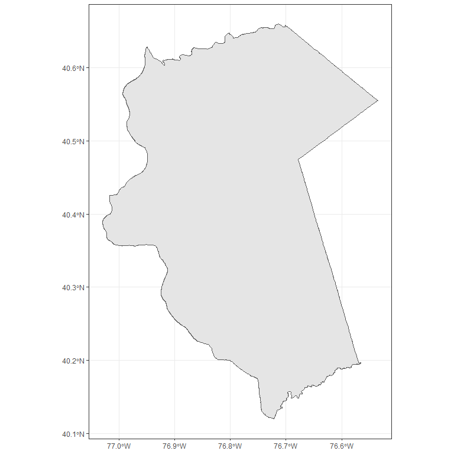

```r
library(ggplot2)

ggplot(map, aes(geometry = geometry)) +
  theme_bw() +
  geom_sf()
```

Lets get all the watersheds in and around our region of interest. `FedData` provides clean access to this information.

**Hint**: `FedData`’s `get_wbd()` and `get_wbd()` functions can be very slow. If you have any interest in looking at the data more than once, make sure to use `extraction.dir`.

**Hint**: When requesting a single boundary, `get_wbd()` has an interesting re-run functionality. On the first call it returns a `data.frame()` of the information we want. On the second call it returns a `list()` of `data.frame()`. To provide a consistent experience we need some hackery.

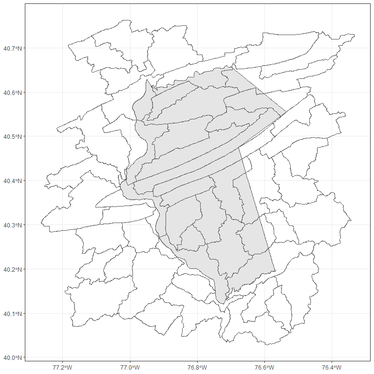

```r
library(FedData)
library(rappdirs)

extraction.dir <- user_cache_dir("FedData")
if(!dir.exists(extraction.dir)) { dir.create(extraction.dir, recursive = T) }

watersheds <-
  get_wbd(
    template = map[, 'geometry'],
    label = county_name,
    extraction.dir = extraction.dir)
if('list' %in% class(watersheds)) { watersheds <- do.call(rbind, watersheds) }

ggplot(map, aes(geometry = geometry)) +
  theme_bw() +
  geom_sf() +
  geom_sf(data = watersheds, aes(geometry = geom), alpha = 0)
```

Lets download the actual streams.

**Hint**: `get_nhd()` has build in looping. This means we can use the full `watersheds` to get all the streams in all the watersheds in the same call. **However**, it is slow to the point of being unusable. Strongly consider using a manual loop.

**Hint**: The more layers on a chart, the harder it can be to tell them apart. We add in an `fill = 'orange'` to help the county pop.

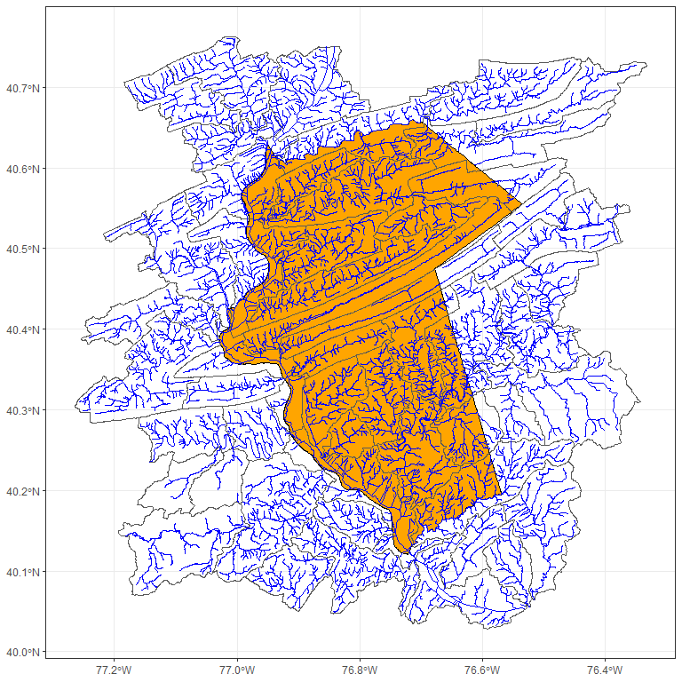

```r
hydro <- vector(mode = 'list', length = nrow(watersheds))
if(interactive()) { pb = txtProgressBar(min = 0, max = nrow(watersheds), style = 3) }
for(i in 1:nrow(watersheds)) {
  tmp <-
    get_nhd(
      template = watersheds[i,],
      label = sprintf('%s_%s', county_name, watersheds$huc12[i]),
      extraction.dir = extraction.dir)
  hydro[[i]] <- tmp$Flowline
  if(interactive()) { setTxtProgressBar(pb, i) }
}
if(interactive()) { close(pb) }
hydro <- do.call(rbind, hydro)

ggplot(map, aes(geometry = geometry)) +
  theme_bw() +
  geom_sf(color = 'black', fill = 'orange') +
  geom_sf(data = watersheds, aes(geometry = geom), alpha = 0) +
  geom_sf(data = hydro, aes(geometry = geom), color = 'blue')
```

Up to this point, all the work has been fairly straightforward mapping. Lets mix-in the data from `dbfishR`.

**Hint**: When mixing polygon `geometry`s with numeric `x` and `y`, you need to either convert the `x` and `y` to a `geometry`, or set `inherit.aes = F`.

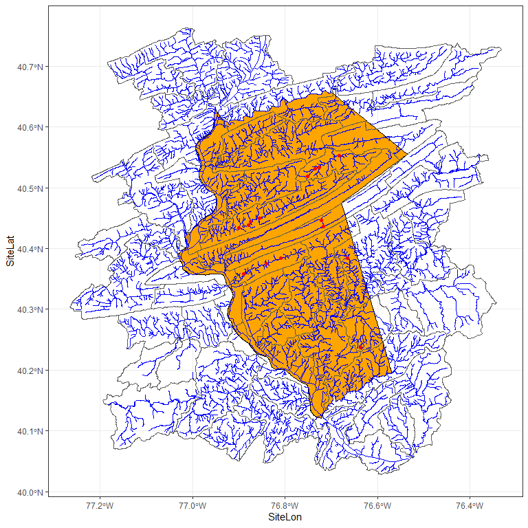

```r
library(dbfishR)

data <-
  get_sites() %>%
  filter(tolower(County) == tolower(county_name))

ggplot(map, aes(geometry = geometry)) +
  theme_bw() +
  geom_sf(color = 'black', fill = 'orange') +
  geom_sf(data = watersheds, aes(geometry = geom), alpha = 0) +
  geom_sf(data = hydro, aes(geometry = geom), color = 'blue') +
  geom_point(data = data, aes(x = SiteLon, y = SiteLat), color = 'red', inherit.aes = F)
```